# Raport z zadania na 3.5

Marta Jóźwik, Ewa Baranowska

12 kwietnia 2017

# 1 Wizualizacje

Rozważymy teraz średnie czasy rozwiązywania zadań w zależności od pozycji, na której znajdywały się pytania.

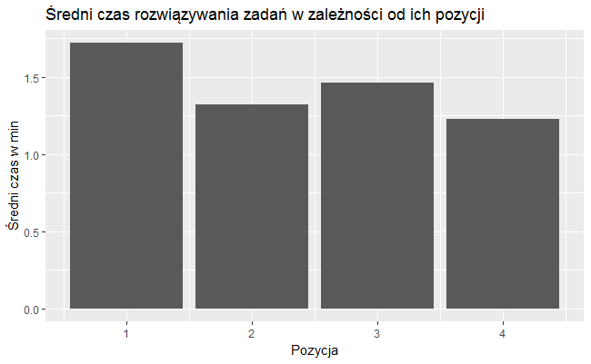

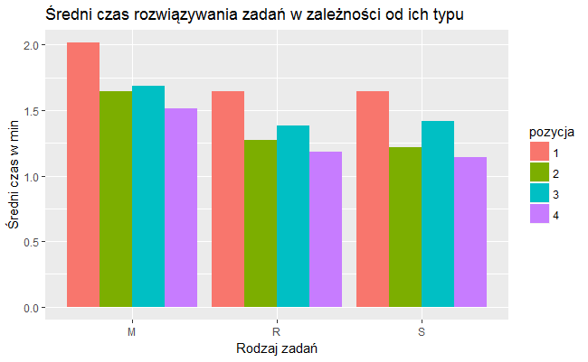

Widać, że zadania na pozycji 1 są średnio rozwiązywane dłużej niż pozostałe, następnie nastepuje skrócenie czasu (możliwe że uczniowie są już wprawieni), potem znów wzrost (np. z powodu zmęczenia),a te na pozycji 4 są rozwiązywane najkrócej (np. uczniowe spieszą się ponieważ zbliża sie koniec egzaminu). Rozbijając zadania na poszczególne typy widzimy identyczną zależność.

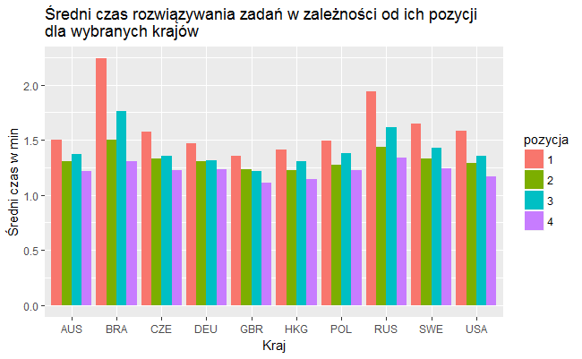

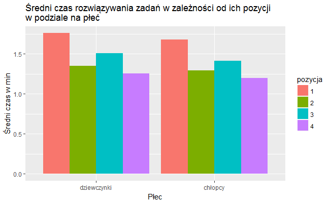

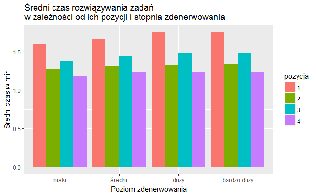

# 2 Testowanie dla typów zadań

Zbadałyśmy też różnicę w średnich czasach w 4 klastrach dla każdego z typów zadań. Zostało to zrobione przy użyciu 3-krotnie jednoczynnikowej ANOVY dla 4 grup (całośc kodu w skrypcie Z3_5.r)

Czasy nie miały rozkładu normalnego, zatem zostały przekształcone dla każdego ze zbiorów transformacją Boxa-Coxa (lambda dla matematyki: 0.292, czytania: 0.25, przyrody: 0.276). Potem wykonałyśmy 3-krotnie ANOVĘ otrzymując następujące średnie w klastrach (średnie liczone z czasów przekształconych) i poziomy krytyczne (stat. testowa, mająca rozkład Snedecora miała parametry: 3 (4 - 1 klastry) oraz drugi parametr: sumie wag dla danego zbioru -3 ) :

matematyka: p-wartość: 0.9972367

```r
load("Z3_5_srednie_czas_klastry_matem.rda")
kable(srednie_matem)
```

| pozycja | srednia |
| --- | --- |
| 1 | 94.02357 |
| 2 | 89.15050 |
| 3 | 89.43916 |
| 4 | 86.66585 |

czytanie: p-wartość: 0.9979847

```r
load("Z3_5_srednie_czas_klastry_read.rda")
kable(srednie_read)
```

| pozycja | srednia |
| --- | --- |
| 1 | 61.29955 |
| 2 | 58.07445 |
| 3 | 59.15115 |
| 4 | 56.80936 |

przyroda: p-wartość: 0.9938741

```r
load("Z3_5_srednie_czas_klastry_science.rda")
kable(srednie_science)
```

| pozycja | srednia |
| --- | --- |
| 1 | 77.61708 |
| 2 | 71.58872 |
| 3 | 74.56616 |
| 4 | 70.04591 |

Widać zatem, że dla żadnego typu zadań nie występuje istotna statystycznie różnica między klastrami w średnich czasach.

# 3 Skrypty

### 3.0.1 Z3_5.r

```r
setwd("C:/Users/E540/Desktop/PISA 2015/zadanie0")
load("Z0_matem_w.rda")
load("Z0_read_w.rda")
load("Z0_science_w.rda")

czyIstotne <- function(zbior){

            require(dplyr)
            require(car)
            require(plotrix)
         # wybieranie kolumn
         zbior %>% dplyr::select(timing, W_FSTUWT, pozycja) -> dane

         # histogram

         #weighted.hist(dane$timing, w =dane$W_FSTUWT, xlim = c(0,1000000), breaks = 1000)

         # usuwanie odstających czasów

         # usuwanie czasow wiekszych niz 10 minut
         dane <- dane %>% filter(timing < 600000)

         # szukanie transformacji
         lambda <- powerTransform(dane$timing, weights= dane$W_FSTUWT)$lambda
         dane$poprawione <- bcPower(dane$timing, lambda= lambda)

         # histogram poprawionych danych
         #weighted.hist(dane$poprawione, w =dane$W_FSTUWT, breaks = 1000)


         # liczenie srednich w grupach i po calosci
         dane %>% group_by(pozycja) %>% summarise( srednia = weighted.mean(poprawione, W_FSTUWT)) -> srednie
         dane %>% summarise( srednia = weighted.mean(poprawione, W_FSTUWT)) -> srednia_calosc

         # liczenie statystyki ANOVU
         SST <- sum( (dane$poprawione - srednia_calosc$srednia)^2 * dane$W_FSTUWT )

         roznica1 <- dane %>% filter(pozycja ==1 ) %>% summarise( roznica = sum((poprawione - as.numeric(srednie[1,2]))^2 * W_FSTUWT ))
         roznica2 <- dane %>% filter(pozycja ==2 ) %>% summarise( roznica = sum((poprawione - as.numeric(srednie[2,2]))^2 * W_FSTUWT ))
         roznica3 <- dane %>% filter(pozycja ==3 ) %>% summarise( roznica = sum((poprawione - as.numeric(srednie[3,2]))^2 * W_FSTUWT ))
         roznica4 <- dane %>% filter(pozycja ==4 ) %>% summarise( roznica = sum((poprawione - as.numeric(srednie[4,2]))^2 * W_FSTUWT ))

         SSE <-  roznica1$roznica + roznica2$roznica + roznica3$roznica + roznica4$roznica

         wagi <- dane %>%  group_by(pozycja) %>% summarise( roznica = sum( W_FSTUWT ))

         SSM <- sum( (srednie$srednia - srednia_calosc$srednia)^2 * wagi$roznica )

         # sprawdzenie
         #SSM + SSE == SST #TRUE

         wagi_calosc <- dane %>% summarise( roznica = sum( W_FSTUWT ))
         wagi_calosc  <- round(wagi_calosc$roznica)
         F_stat <- SSM/SSE

         return(list(pvalue= (1 -pf(F_stat, 3, wagi_calosc - 3)),srednie =srednie, lambda=lambda))
         #qf(0.05, 3, wagi_calosc -3)
}

# matematyka
wyniki_matem <- czyIstotne(Z0_matem)
wyniki_matem$pvalue #0.9972367
srednie_matem <- wyniki_matem$srednie
save(srednie_matem, file="Z3_5_srednie_czas_klastry_matem.rda")
rm(Z0_matem)

# czytanie
wyniki_read <- czyIstotne(Z0_read)
wyniki_read$pvalue #0.9979847
srednie_read <- wyniki_read$srednie
save(srednie_read, file="Z3_5_srednie_czas_klastry_read.rda")
rm(Z0_read)

# przyroda
wyniki_science <- czyIstotne(Z0_science)
wyniki_science$pvalue #0.9938741
srednie_science <- wyniki_science$srednie
save(srednie_science, file="Z3_5_srednie_czas_klastry_science.rda")
rm(Z0_science)
```